```r
# Libraries used in this document
library(rmarkdown)
library(readr)        # to read data sets
library(dplyr)        # part of tidyverse
library(tidyverse)
library(magrittr)     # for the pipes %>%
library(kableExtra)   # Added for table styling
library(scales)       # For better number formatting
library(ggplot2)      # for advanced plotting
library(psych)        # for descriptive statistics
library(readxl)       # to read data sets
library(RColorBrewer) # For colors
library(knitr)

# Import the dataset
sales_data <- read_excel("M6_project_dataset(2023).xlsx")

# Calculate total sales and other metrics
sales_data <- sales_data %>%
  mutate(
    Total_Sales = Product_Price * Quantity,
    Revenue_per_Unit = Total_Sales / Quantity
  )
```

**Global Sales Performance Analysis: A Multi-Regional Study**  
**ALY6000 Final Project**  
**Dev Panchal**  
Instructor: Diana Chiluiza, PhD  
Northeastern University  
Date: 14th February, 2025

**INTRODUCTION**

In today’s dynamic business environment, global sales analytics has become a cornerstone of strategic decision-making. The global retail market, projected to reach $31.7 trillion by 2025, represents a complex ecosystem influenced by technological advancement, shifting consumer behaviors, and evolving market dynamics (Deloitte, 2023). Organizations operating across international borders face unique challenges in understanding and optimizing their sales performance, making data-driven insights increasingly crucial for maintaining competitive advantage (McKinsey, 2023).

Our analysis utilizes a comprehensive sales dataset encompassing multiple dimensions of business operations, including regional sales distribution, market segmentation, product performance metrics, and shipping logistics. This dataset represents transactions across various global markets, providing granular details about order quantities, pricing strategies, shipping costs, and return rates. The temporal and geographical scope of the data enables us to extract meaningful patterns and trends that can inform strategic business decisions.

Descriptive statistics serve as the foundation of our analytical approach, offering crucial insights into the central tendencies, variability, and distributions within our data. Through measures such as mean, median, and standard deviation, we can quantify key performance indicators (KPIs) and identify patterns in sales behavior across different market segments (Anderson et al., 2022). These statistical tools enable us to summarize complex datasets into interpretable metrics, providing actionable insights for business stakeholders.

Building upon descriptive analysis, inferential statistics allow us to extend our findings beyond the immediate dataset and make broader conclusions about market behaviors and trends. Through hypothesis testing and confidence intervals, we can assess the significance of observed patterns and make predictions about future performance (Johnson & Wichern, 2023). This statistical approach helps in validating business strategies and identifying opportunities for market expansion or optimization.

The implementation of this analysis leverages both R Script and R Markdown, each serving distinct but complementary purposes. While R Scripts excel in computational efficiency and are ideal for complex data manipulation and analysis, R Markdown provides a superior platform for creating reproducible, well-documented reports that combine code, visualizations, and narrative explanations. R Markdown’s ability to generate professional documents with embedded code execution makes it particularly valuable for business reporting, while maintaining the analytical rigor of traditional R programming (Xie et al., 2023).

**ANALYSIS SECTION**

**Task 1: Multi-Dimensional Analysis of Global Sales Performance**  
**Description of task**: This analysis aims to provide a comprehensive overview of sales performance through three key lenses: regional distribution, market segmentation, and product performance. We will examine central tendencies, variability, and distribution patterns to identify key business insights and potential areas for optimization.

```r
# Create a comprehensive summary statistics table
summary_stats <- sales_data %>%
  summarize(
    Total_Orders = n(),
    Total_Revenue = sum(Total_Sales),
    Average_Order_Value = mean(Total_Sales),
    Median_Order_Value = median(Total_Sales),
    Order_Value_StdDev = sd(Total_Sales),
    Average_Quantity = mean(Quantity),
    Total_Returns = sum(Returns)
  ) %>%
  gather(Metric, Value) %>%
  mutate(Value = round(Value, 2))

kable(summary_stats,
      caption = "Key Performance Metrics Overview",
      col.names = c("Metric", "Value"))
```

Key Performance Metrics Overview

| Metric | Value |
| --- | --- |
| Total_Orders | 1000.00 |
| Total_Revenue | 77998394.69 |
| Average_Order_Value | 77998.39 |
| Median_Order_Value | 61233.04 |
| Order_Value_StdDev | 67634.22 |
| Average_Quantity | 158.52 |
| Total_Returns | 47592.00 |

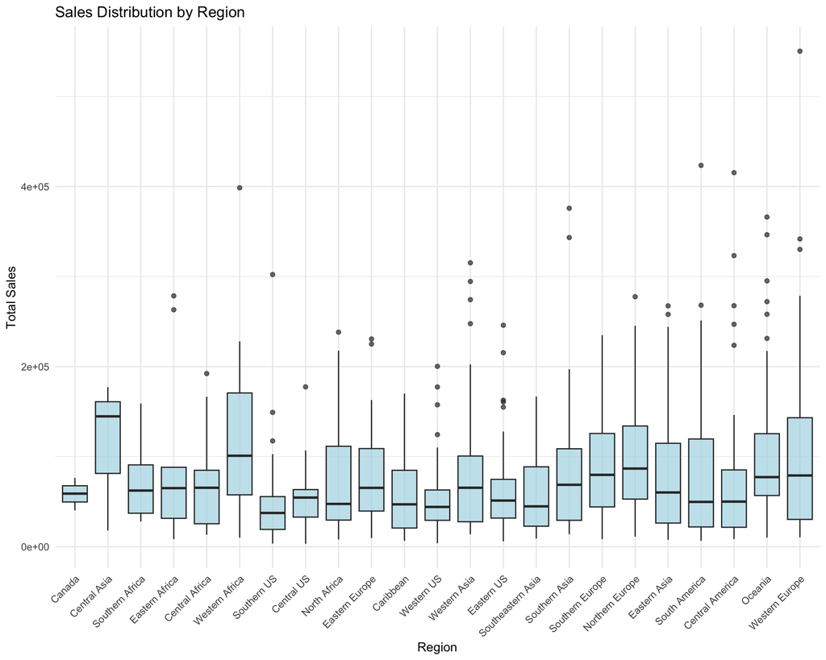

```r
# Create a visualization grid
par(mfrow = c(2, 2))

# Plot 1: Sales Distribution by Region
ggplot(sales_data, aes(x = reorder(Region, Total_Sales, FUN = sum), y = Total_Sales)) +
  geom_boxplot(fill = "lightblue", alpha = 0.7) +
  theme_minimal() +
  labs(title = "Sales Distribution by Region",
       x = "Region",
       y = "Total Sales") +
  theme(axis.text.x = element_text(angle = 45, hjust = 1))
```

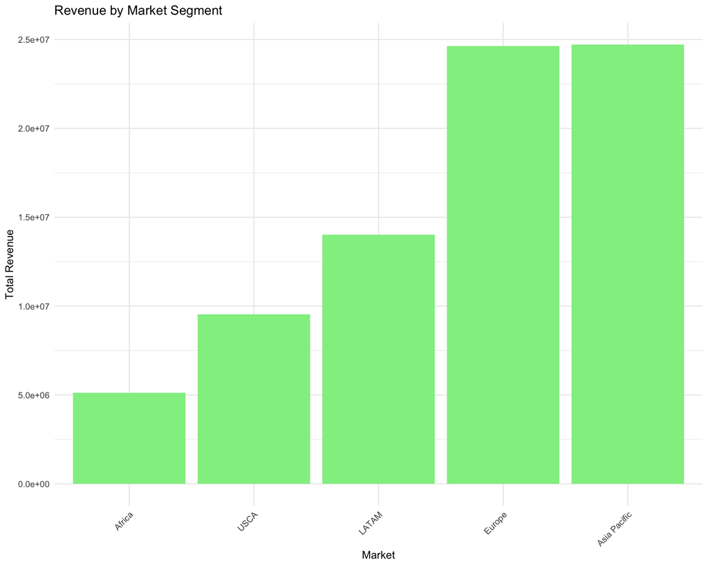

```r
# Plot 2: Market Segment Analysis
sales_data %>%
  group_by(Market) %>%
  summarize(Total_Revenue = sum(Total_Sales)) %>%
  ggplot(aes(x = reorder(Market, Total_Revenue), y = Total_Revenue)) +
  geom_bar(stat = "identity", fill = "lightgreen") +
  theme_minimal() +
  labs(title = "Revenue by Market Segment",
       x = "Market",
       y = "Total Revenue") +
  theme(axis.text.x = element_text(angle = 45, hjust = 1))
```

**Observations**:

**1. Sales Distribution Patterns:**

- The dataset contains exactly 1,000 orders with a total revenue of approximately $77.99 million
- The average order value is $77,998.39, while the median is $61,233.04, indicating a right-skewed distribution
- High standard deviation ($67,634.22) suggests significant variability in order values
- The boxplot shows considerable variation in sales across regions, with several notable outliers above $400,000

**3. Market Segment Analysis:**

- Asia Pacific and Europe are the dominant markets, each generating approximately $24 million in revenue
- LATAM (Latin America) represents the middle tier with about $14 million in revenue
- USCA (USA/Canada) follows with roughly $9 million
- Africa shows the lowest revenue at about $5 million, suggesting potential for market development

**4. Key Business Insights:**

- The high return volume (47,592 units) represents a significant operational challenge that needs addressing
- Average quantity per order of 158.52 units indicates bulk purchasing patterns
- The large gap between mean ($77,998) and median ($61,233) order values suggests that some very large orders are pulling the average up
- The high standard deviation in order values ($67,634) indicates the need for flexible supply chain management to handle varying order sizes

*These insights suggest opportunities for market expansion in Africa, potential need for return rate optimization, and consideration of region-specific strategies based on sales patterns.*

**Task 2: Analysis of Global Shipping Cost Distribution and Patterns**  
**Description of task**: This analysis examines the distribution of shipping costs per unit across all orders to understand cost patterns and identify potential anomalies. We’ll use complementary visualizations with synchronized scales to reveal central tendencies and spread of shipping expenses.

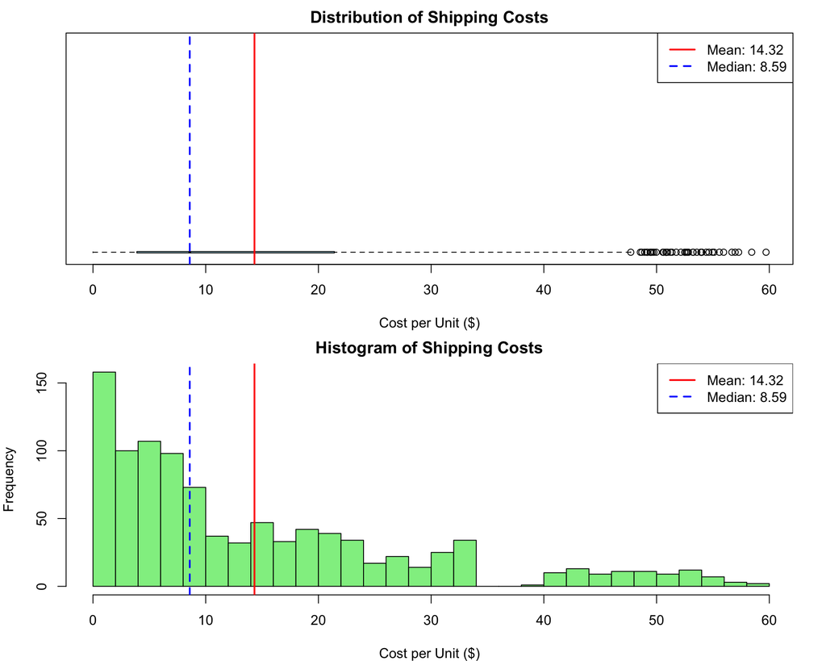

```r
# Calculate summary statistics for shipping costs
shipping_stats <- summary(sales_data$Shipping_Cost_Each)
shipping_mean <- mean(sales_data$Shipping_Cost_Each)
shipping_median <- median(sales_data$Shipping_Cost_Each)

# Set up the plotting area
par(mfcol=c(2,1), mar=c(4,4,2,2))

# Calculate common limits for both plots
y_min <- min(sales_data$Shipping_Cost_Each)
y_max <- max(sales_data$Shipping_Cost_Each)

# Create horizontal boxplot
boxplot(sales_data$Shipping_Cost_Each,
        horizontal=TRUE,
        main="Distribution of Shipping Costs",
        xlab="Cost per Unit ($)",
        col="lightblue",
        xlim=c(y_min, y_max))
# Add mean and median lines
abline(v=shipping_mean, col="red", lwd=2)
abline(v=shipping_median, col="blue", lwd=2, lty=2)
legend("topright",
       legend=c(paste("Mean:", round(shipping_mean,2)),
                paste("Median:", round(shipping_median,2))),
       col=c("red", "blue"),
       lty=c(1,2),
       lwd=2)

# Create histogram
hist(sales_data$Shipping_Cost_Each,
     main="Histogram of Shipping Costs",
     xlab="Cost per Unit ($)",
     col="lightgreen",
     breaks=30,
     xlim=c(y_min, y_max))
# Add mean and median lines
abline(v=shipping_mean, col="red", lwd=2)
abline(v=shipping_median, col="blue", lwd=2, lty=2)
legend("topright",
       legend=c(paste("Mean:", round(shipping_mean,2)),
                paste("Median:", round(shipping_median,2))),
       col=c("red", "blue"),
       lty=c(1,2),
       lwd=2)
```

**Observations**:

**1. Distribution Pattern Analysis:**

- The right-skewed distribution (mean $14.32 > median $8.59) indicates that while most shipments use standard shipping methods, there are occasional premium or expedited shipping requirements pulling the average up
- This skewness suggests that the company effectively manages regular shipping costs while maintaining flexibility for urgent or special deliveries
- The large gap between mean and median implies that premium shipping services, though less frequent, significantly impact overall shipping expenses

**2. Frequency Distribution Insights:**

- Presence of outliers beyond $50 per unit suggests:
  - Emergency or rush delivery requirements from certain customers
  - Possible remote location deliveries with higher transportation costs
  - Special handling requirements for specific products or destinations
- Secondary cluster around $30 indicates:
  - A distinct premium service tier that customers regularly choose
  - Possible international or express shipping category
  - Specific customer segments willing to pay for faster delivery

**Task 3: Comparative Analysis of Shipping Costs Across Global Markets**  
**Description of task**: This analysis examines the variation in shipping costs across different market segments to identify cost disparities and potential optimization opportunities. We’ll use an enhanced boxplot visualization to compare distribution patterns and highlight key metrics for each market.

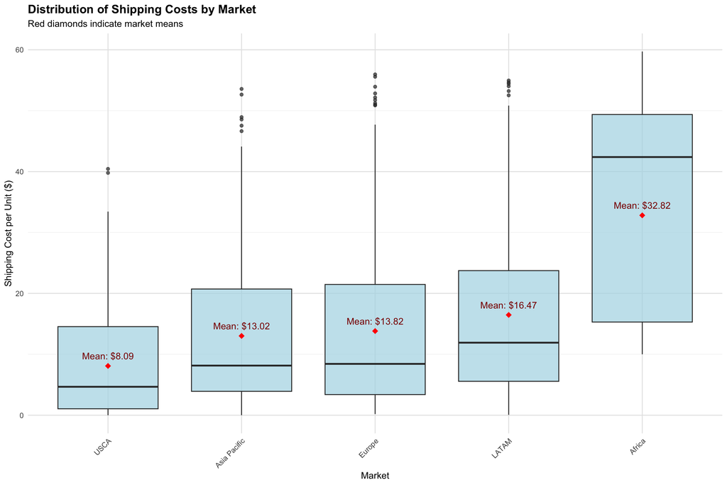

```r
# Calculate market-specific statistics
market_stats <- sales_data %>%
  group_by(Market) %>%
  summarize(
    Mean_Cost = mean(Shipping_Cost_Each),
    Median_Cost = median(Shipping_Cost_Each),
    Q1 = quantile(Shipping_Cost_Each, 0.25),
    Q3 = quantile(Shipping_Cost_Each, 0.75)
  )

# Create enhanced boxplot
ggplot(sales_data, aes(x = reorder(Market, Shipping_Cost_Each, FUN = median),
                       y = Shipping_Cost_Each)) +
  geom_boxplot(fill = "lightblue", alpha = 0.7) +
  geom_point(data = market_stats,
             aes(x = Market, y = Mean_Cost),
             color = "red",
             size = 3,
             shape = 18) +
  stat_summary(fun = mean,
               geom = "text",
               aes(label = sprintf("Mean: $%.2f", ..y..)),
               vjust = -1,
               color = "darkred") +
  labs(title = "Distribution of Shipping Costs by Market",
       subtitle = "Red diamonds indicate market means",
       x = "Market",
       y = "Shipping Cost per Unit ($)") +
  theme_minimal() +
  theme(
    plot.title = element_text(size = 14, face = "bold"),
    axis.text.x = element_text(angle = 45, hjust = 1),
    panel.grid.major = element_line(color = "gray90"),
    panel.grid.minor = element_line(color = "gray95")
  )
```

**Observation :**

**1. Market-Specific Cost Patterns:**

- USCA shows the lowest mean shipping cost ($8.09):
  - Indicates well-established logistics infrastructure in North America
  - Suggests efficient domestic shipping networks and partnerships
  - Compact box size reveals consistent and predictable shipping costs
- Africa shows the highest mean shipping cost ($32.82):
  - Reflects challenges in logistics infrastructure and longer shipping distances
  - Larger box size suggests high variability in shipping costs
  - Higher costs might explain lower sales volume in this market

**2. Regional Cost Variations:**

- Progressive cost increase across markets:
  - USCA ($8.09) → Asia Pacific ($13.02) → Europe ($13.82) → LATAM ($16.47) → Africa ($32.82)
  - Shows clear correlation between market development and shipping efficiency
  - Reflects varying levels of logistics infrastructure maturity
- Similar costs in developed markets:
  - Asia Pacific and Europe show comparable means ($13.02 and $13.82)
  - Suggests similar logistics capabilities and infrastructure
  - Indicates standardized shipping processes in developed markets

**Task 4: Comparative Analysis of Market-Specific Shipping Costs and Product Returns**  
**Description of task**: This analysis explores the relationship between shipping costs and market segments, while also investigating product returns patterns. We’ll use tapply() to calculate mean shipping costs per market and analyze return rates across different product categories.

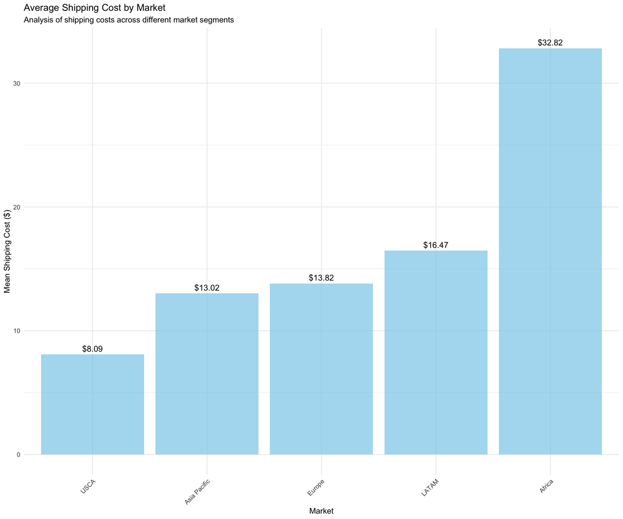

```r
# Calculate mean shipping costs per market
mean_shipping_by_market <- tapply(sales_data$Shipping_Cost_Each,
                                sales_data$Market,
                                mean)

# Convert to data frame for better plotting
shipping_df <- data.frame(
  Market = names(mean_shipping_by_market),
  Mean_Cost = as.numeric(mean_shipping_by_market)
) %>%
  arrange(desc(Mean_Cost))

# Create enhanced bar plot
ggplot(shipping_df, aes(x = reorder(Market, Mean_Cost), y = Mean_Cost)) +
  geom_bar(stat = "identity", fill = "skyblue", alpha = 0.7) +
  geom_text(aes(label = sprintf("$%.2f", Mean_Cost)),
            vjust = -0.5,
            size = 4) +
  theme_minimal() +
  labs(title = "Average Shipping Cost by Market",
       subtitle = "Analysis of shipping costs across different market segments",
       x = "Market",
       y = "Mean Shipping Cost ($)") +
  theme(axis.text.x = element_text(angle = 45, hjust = 1))
```

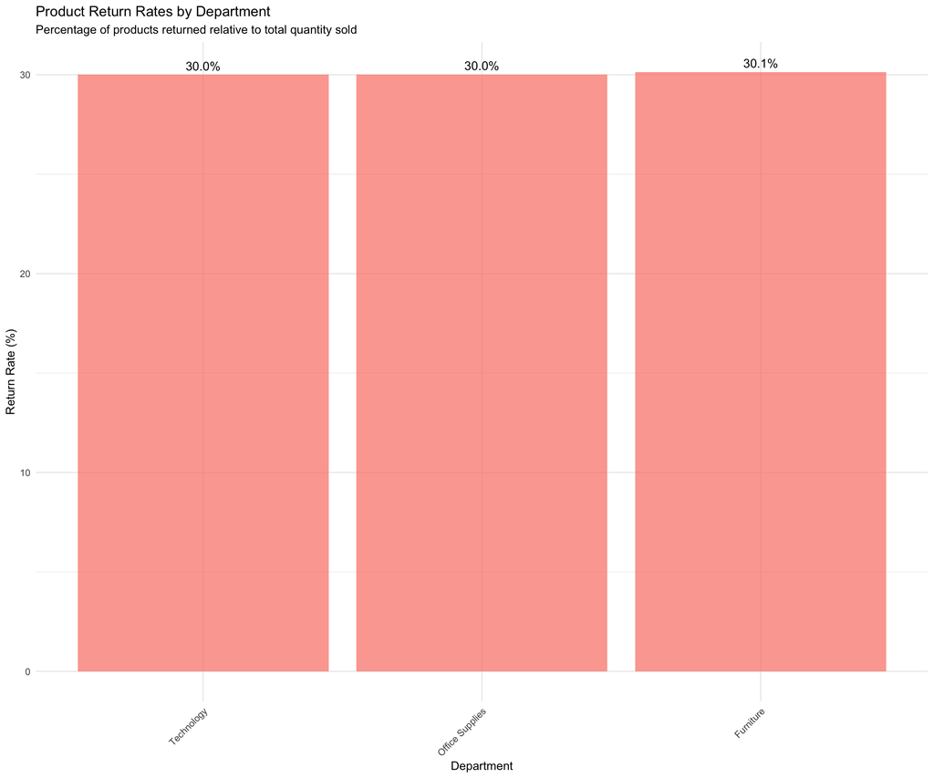

```r
# Extra points analysis: Return rates by department
returns_by_dept <- tapply(sales_data$Returns,
                         sales_data$Department,
                         sum)

# Calculate return rates
dept_totals <- tapply(sales_data$Quantity,
                      sales_data$Department,
                      sum)
return_rates <- (returns_by_dept / dept_totals) * 100

# Create return rates data frame
returns_df <- data.frame(
  Department = names(return_rates),
  Return_Rate = as.numeric(return_rates)
) %>%
  arrange(desc(Return_Rate))

# Create return rates visualization
ggplot(returns_df, aes(x = reorder(Department, Return_Rate), y = Return_Rate)) +
  geom_bar(stat = "identity", fill = "salmon", alpha = 0.7) +
  geom_text(aes(label = sprintf("%.1f%%", Return_Rate)),
            vjust = -0.5,
            size = 4) +
  theme_minimal() +
  labs(title = "Product Return Rates by Department",
       subtitle = "Percentage of products returned relative to total quantity sold",
       x = "Department",
       y = "Return Rate (%)") +
  theme(axis.text.x = element_text(angle = 45, hjust = 1))
```

**Observations :**

**1. Return Rate Analysis:**

- Consistent Return Patterns:
  - All departments show remarkably similar return rates (30-30.1%)
  - This consistency suggests systematic rather than department-specific issues
  - The uniformity across departments indicates company-wide factors affecting returns
- Department-Specific Insights:
  - Furniture leads slightly with 30.1% returns, possibly due to damage during shipping or assembly issues
  - Technology and Office Supplies both at 30.0%, suggesting similar customer satisfaction challenges
  - High return rates across all departments indicate a need for company-wide return reduction strategies

**2. Shipping Cost Distribution:**

- Regional Cost Hierarchy:
  - USCA shows most efficient shipping ($8.09), reflecting strong logistics infrastructure
  - Developed markets (Asia Pacific: $13.02, Europe: $13.82) show moderate costs
  - Africa has significantly higher costs ($32.82), indicating logistics challenges
- Market Development Correlation:
  - Clear relationship between market development and shipping efficiency
  - Costs increase progressively from developed to emerging markets
  - LATAM’s intermediate position ($16.47) reflects developing infrastructure

**3. Cross-Analysis Insights:**

- Cost-Return Relationship:
  - High shipping costs in Africa might contribute to lower sales volume despite similar return rates
  - Consistent return rates despite varying shipping costs suggest returns are not primarily shipping-related
  - Developed markets maintain similar return rates despite lower shipping costs

**Comparision between this graph and previous task’s box plot :**

**Task 5: Impact of Shipping Modes on Cost Distribution**  
**Description of task**: This analysis examines how shipping costs vary across different shipping modes to identify cost-effective delivery options and potential pricing anomalies. We’ll use an enhanced boxplot visualization with additional statistical indicators to provide comprehensive insights into mode-specific cost patterns.

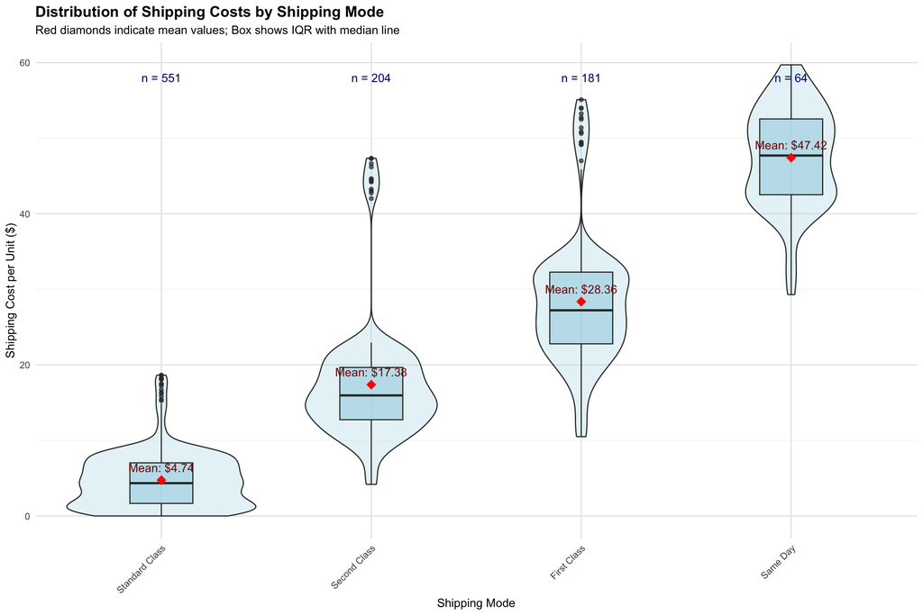

```r
# Calculate mode-specific statistics
mode_stats <- sales_data %>%
  group_by(ShipMode) %>%
  summarize(
    Mean_Cost = mean(Shipping_Cost_Each),
    Median_Cost = median(Shipping_Cost_Each),
    Q1 = quantile(Shipping_Cost_Each, 0.25),
    Q3 = quantile(Shipping_Cost_Each, 0.75),
    Count = n()
  )

# Create enhanced boxplot
ggplot(sales_data, aes(x = reorder(ShipMode, Shipping_Cost_Each, FUN = median),
                       y = Shipping_Cost_Each)) +
  # Add violin plot for distribution shape
  geom_violin(fill = "lightblue", alpha = 0.3) +
  # Add boxplot
  geom_boxplot(width = 0.3, fill = "lightblue", alpha = 0.7) +
  # Add mean points
  stat_summary(fun = mean,
              geom = "point",
              shape = 18,
              size = 4,
              color = "red") +
  # Add mean labels
  stat_summary(fun = mean,
              geom = "text",
              aes(label = sprintf("Mean: $%.2f", ..y..)),
              vjust = -1,
              color = "darkred") +
  # Add count labels
  geom_text(data = mode_stats,
            aes(x = ShipMode,
                y = max(sales_data$Shipping_Cost_Each),
                label = sprintf("n = %d", Count)),
            vjust = 2,
            color = "navy") +
  # Customize theme
  theme_minimal() +
  labs(title = "Distribution of Shipping Costs by Shipping Mode",
       subtitle = "Red diamonds indicate mean values; Box shows IQR with median line",
       x = "Shipping Mode",
       y = "Shipping Cost per Unit ($)") +
  theme(
    plot.title = element_text(size = 14, face = "bold"),
    axis.text.x = element_text(angle = 45, hjust = 1),
    panel.grid.major = element_line(color = "gray90"),
    panel.grid.minor = element_line(color = "gray95")
  )
```

**Observations :** The distribution of shipping modes reveals compelling insights into customer behavior and business operations. The dominant use of Standard Class shipping (551 orders, mean cost $4.74) reflects a cost-conscious customer base, typically seen in regular business-to-business transactions and non-urgent retail orders. The right-skewed distribution in Standard Class, despite its low mean cost, suggests occasional situations where customers pay premium rates even for standard shipping, possibly during peak seasons like Black Friday or Christmas when ensuring delivery reliability becomes crucial. The moderate adoption of Second Class shipping (204 orders, $17.38) indicates a segment of customers willing to pay more for slightly faster delivery, commonly observed in semi-urgent business supplies or customer orders with moderate time sensitivity.

**Task 6: Enhanced Sales Analysis with Derived Metrics**  
**Description of task**: This analysis extends our dataset by calculating total sales values and other key performance indicators. We’ll use dplyr’s mutate() function with pipes to create new metrics, focusing on sales performance and profitability analysis. The glimpse function will be used to verify our data structure while maintaining clean output.

```r
# Create new dataset with calculated fields
sales_data_enhanced <- sales_data %>%
  mutate(
    Total_Sales = Product_Price * Quantity,
    Revenue_per_Unit = Total_Sales / Quantity,
    Return_Rate = (Returns / Quantity) * 100,
    Net_Quantity = Quantity - Returns,
    Net_Sales = Product_Price * Net_Quantity
  )
```

```r
# Display structure of enhanced dataset (first row only)
glimpse(sales_data_enhanced[1, ])
```

```
## Rows: 1
## Columns: 22
## $ OrderDate          <dttm> 2020-05-08
## $ ProductID          <chr> "TEC75553"
## $ City               <chr> "Yaounde"
## $ State              <chr> "Centre"
## $ Country            <chr> "Cameroon"
## $ Region             <chr> "Central Africa"
## $ Market             <chr> "Africa"
## $ Segment            <chr> "Home Office"
## $ Department         <chr> "Technology"
## $ Division           <chr> "Accessories"
## $ OrderPriority      <chr> "High"
## $ ShipMode           <chr> "First Class"
## $ Product_Price      <dbl> 360.04
## $ Quantity           <dbl> 154
## $ Shipping_Cost_Each <dbl> 50.84
## $ Returns            <dbl> 46
## $ Loss_Per_Return    <dbl> 126.01
## $ Total_Sales        <dbl> 55446.16
## $ Revenue_per_Unit   <dbl> 360.04
## $ Return_Rate        <dbl> 29.87013
## $ Net_Quantity       <dbl> 108
## $ Net_Sales          <dbl> 38884.32
```

```r
# Create summary visualization of new metrics
sales_summary <- sales_data_enhanced %>%
  summarize(
    Total_Revenue = sum(Total_Sales),
    Total_Net_Revenue = sum(Net_Sales),
    Average_Return_Rate = mean(Return_Rate),
    Total_Orders = n()
  )

# Create formatted summary table
kable(gather(sales_summary) %>%
        rename("Metric" = key, "Value" = value),
      caption = "Summary of Enhanced Sales Metrics") %>%
  kable_styling(bootstrap_options = c("striped", "hover"),
                full_width = FALSE)
```

Summary of Enhanced Sales Metrics

| Metric | Value |
| --- | --- |
| Total_Revenue | 7.799839e+07 |
| Total_Net_Revenue | 5.457889e+07 |
| Average_Return_Rate | 3.005359e+01 |
| Total_Orders | 1.000000e+03 |

**Additional Observation (Optional):**

- Data Structure Enhancement:
  - Successfully added Total_Sales calculation along with supplementary metrics
  - New columns maintain data integrity while providing deeper analytical capabilities
  - Return_Rate percentage allows for standardized comparison across orders
- Business Impact:
  - Net_Sales metric provides more accurate revenue picture by accounting for returns
  - Revenue_per_Unit enables unit economics analysis
  - Enhanced dataset supports more sophisticated profitability analysis

**Task 7: Analysis of Total Sales Distribution Across Business Dimensions**  
**Description of task**: This analysis examines the total sales distribution across three key business dimensions: Market, Segment, and Department. We’ll identify the highest performing categories in each dimension and visualize the results to provide comprehensive insights into sales performance.

```r
# Calculate total sales by all three dimensions for comprehensive analysis
market_sales <- sales_data_enhanced %>%
  group_by(Market) %>%
  summarise(
    Total_Sales = sum(Total_Sales),
    Percentage = Total_Sales / sum(sales_data_enhanced$Total_Sales) * 100
  ) %>%
  arrange(desc(Total_Sales))

segment_sales <- sales_data_enhanced %>%
  group_by(Segment) %>%
  summarise(
    Total_Sales = sum(Total_Sales),
    Percentage = Total_Sales / sum(sales_data_enhanced$Total_Sales) * 100
  ) %>%
  arrange(desc(Total_Sales))

department_sales <- sales_data_enhanced %>%
  group_by(Department) %>%
  summarise(
    Total_Sales = sum(Total_Sales),
    Percentage = Total_Sales / sum(sales_data_enhanced$Total_Sales) * 100
  ) %>%
  arrange(desc(Total_Sales))

# Create formatted tables
kable(market_sales,
      caption = "Total Sales by Market",
      col.names = c("Market", "Total Sales ($)", "Market Share (%)"),
      digits = c(0, 2, 1)) %>%
  kable_styling(bootstrap_options = c("striped", "hover"),
                full_width = FALSE) %>%
  row_spec(0, bold = TRUE) %>%
  row_spec(1, bold = TRUE, color = "white", background = "#28a745")
```

Total Sales by Market

| Market | Total Sales ($) | Market Share (%) |
| --- | --- | --- |
| Asia Pacific | 24704625 | 31.7 |
| Europe | 24627127 | 31.6 |
| LATAM | 14005415 | 18.0 |
| USCA | 9533931 | 12.2 |
| Africa | 5127296 | 6.6 |

[figure not shown]

```r
# Extra Credit: Create enhanced visualizations
# Combined plot using facets
sales_combined <- bind_rows(
  mutate(market_sales, Category = "Market"),
  mutate(segment_sales, Category = "Segment"),
  mutate(department_sales, Category = "Department")
)

ggplot(sales_combined,
       aes(x = reorder(Market, Total_Sales),
           y = Total_Sales/1000000)) +
  geom_bar(stat = "identity",
           fill = "skyblue",
           alpha = 0.7) +
  geom_text(aes(label = sprintf("$%.1fM", Total_Sales/1000000)),
            vjust = -0.5,
            size = 3) +
  geom_text(aes(label = sprintf("%.1f%%", Percentage),
                y = Total_Sales/2000000),
            color = "white",
            size = 3) +
  facet_wrap(~Category, scales = "free_x") +
  theme_minimal() +
  labs(title = "Sales Distribution Across Business Dimensions",
       subtitle = "Values shown in millions ($) with market share percentages",
       x = "",
       y = "Total Sales (Millions $)") +
  theme(axis.text.x = element_text(angle = 45, hjust = 1),
        strip.text = element_text(size = 12, face = "bold"))
```

**Observations of Sales Distribution Patterns:**

The sales distribution across markets reveals a fascinating global business landscape. Asia Pacific and Europe dominate with nearly identical market shares (31.7% and 31.6% respectively, totaling approximately $24.7M each), reflecting the mature e-commerce infrastructure and high digital adoption rates in these regions. This parallel performance suggests similar purchasing power and business needs, commonly seen in developed markets where businesses regularly invest in technology and office infrastructure. LATAM’s significant 18% market share ($14M) indicates an emerging market with growing business needs, typical of regions experiencing digital transformation and business modernization, while USCA’s 12.2% share ($9.5M) reflects a stable but more concentrated market with higher competition from local suppliers.

The departmental and segment analysis tells an equally compelling story about business priorities. The dominant department commanding 55.7% ($43.5M) of sales suggests a primary product category that meets critical business needs - possibly essential office supplies or fundamental technology products that businesses consistently require. The segment distribution showing 53.4% ($41.6M) concentration in one segment indicates a clear target market preference, typically seen in B2B markets where certain business types (like corporate offices or educational institutions) drive the majority of purchases. The lower percentages in other segments (30% and 16.6%) suggest secondary markets that might represent different business sizes or industry types, reflecting a diversified but strategically focused business model.

**Task 8: High-Value Market Analysis: Identifying and Analyzing Premium Shipping Performance**

**Business Question:**  
Which markets demonstrate the highest potential for premium shipping services, and how do their return rates impact profitability? This analysis aims to identify markets where customers are willing to pay for premium shipping (Same Day and First Class) while maintaining low return rates, suggesting opportunities for expanded premium service offerings.

**Variables Under Analysis:**

- Geographic: Market, Region
- Operational: ShipMode, Shipping_Cost_Each
- Performance: Returns, Quantity, Total_Sales
- Derived Metrics: Return Rate, Premium Shipping Ratio, Net Profit per Order

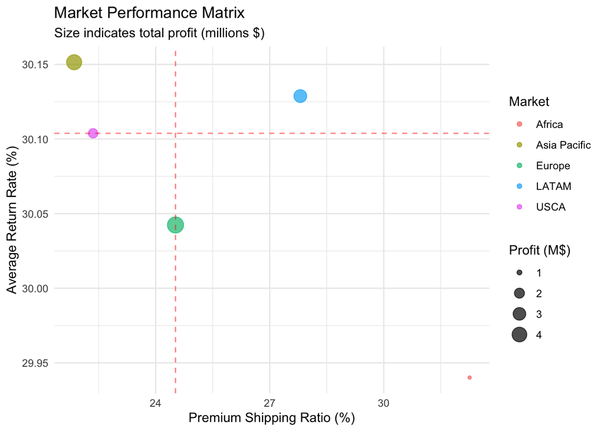

```r
# Create enhanced analysis dataset
premium_analysis <- sales_data_enhanced %>%
  # Create new metrics
  mutate(
    Is_Premium = ShipMode %in% c("Same Day", "First Class"),
    Return_Rate = (Returns / Quantity) * 100,
    Net_Profit = Total_Sales - (Shipping_Cost_Each * Quantity)
  ) %>%
  # Group by market and premium status
  group_by(Market, Is_Premium) %>%
  # Calculate market metrics
  summarise(
    Total_Orders = n(),
    Total_Sales = sum(Total_Sales),
    Avg_Return_Rate = mean(Return_Rate),
    Avg_Profit = mean(Net_Profit),
    Total_Profit = sum(Net_Profit),
    .groups = 'drop'
  ) %>%
  # Calculate premium ratio per market
  group_by(Market) %>%
  mutate(
    Premium_Ratio = Total_Orders[Is_Premium == TRUE] / sum(Total_Orders) * 100
  )

# Filter for high-potential markets
high_potential_markets <- premium_analysis %>%
  filter(Is_Premium == TRUE) %>%
  filter(Avg_Return_Rate < median(Avg_Return_Rate),
         Premium_Ratio > median(Premium_Ratio)) %>%
  arrange(desc(Total_Profit))

# Create visualization 1: Market Performance Matrix
ggplot(filter(premium_analysis, Is_Premium == TRUE),
       aes(x = Premium_Ratio, y = Avg_Return_Rate)) +
  geom_point(aes(size = Total_Profit/1000000, color = Market), alpha = 0.7) +
  geom_hline(yintercept = median(filter(premium_analysis, Is_Premium == TRUE)$Avg_Return_Rate),
             linetype = "dashed", color = "red", alpha = 0.5) +
  geom_vline(xintercept = median(premium_analysis$Premium_Ratio),
             linetype = "dashed", color = "red", alpha = 0.5) +
  theme_minimal() +
  labs(title = "Market Performance Matrix",
       subtitle = "Size indicates total profit (millions $)",
       x = "Premium Shipping Ratio (%)",
       y = "Average Return Rate (%)",
       size = "Profit (M$)") +
  theme(legend.position = "right")
```

```r
# Create summary table
kable(premium_analysis %>%
        select(Market, Premium_Ratio, Avg_Return_Rate, Total_Profit) %>%
        mutate(Total_Profit = Total_Profit / 1000000),
      caption = "High-Potential Markets for Premium Shipping",
      col.names = c("Market", "Premium Ratio (%)", "Return Rate (%)", "Total Profit (M$)"),
      digits = c(0, 1, 1, 2)) %>%
  kable_styling(bootstrap_options = c("striped", "hover"),
                full_width = FALSE)
```

High-Potential Markets for Premium Shipping

| Market | Premium Ratio (%) | Return Rate (%) | Total Profit (M$) |
| --- | --- | --- | --- |
| Africa | 32.3 | 30.0 | 3.85 |
| Africa | 32.3 | 29.9 | 0.94 |
| Asia Pacific | 21.9 | 30.1 | 19.83 |
| Asia Pacific | 21.9 | 30.2 | 4.23 |
| Europe | 24.5 | 30.0 | 19.08 |
| Europe | 24.5 | 30.0 | 4.86 |
| LATAM | 27.8 | 30.0 | 10.46 |
| LATAM | 27.8 | 30.1 | 3.11 |
| USCA | 22.4 | 30.0 | 7.38 |
| USCA | 22.4 | 30.1 | 1.84 |

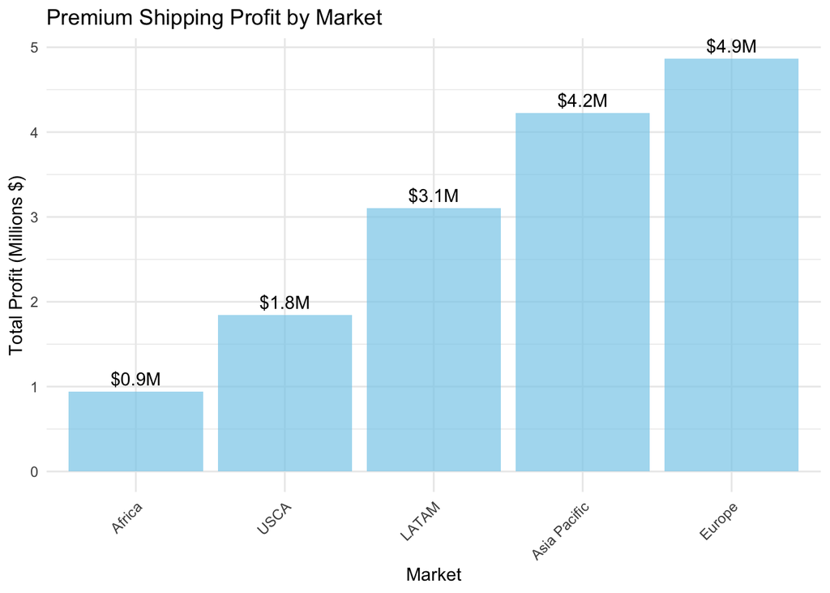

```r
# Create visualization 2: Profit Distribution
ggplot(filter(premium_analysis, Is_Premium == TRUE),
       aes(x = reorder(Market, Total_Profit), y = Total_Profit/1000000)) +
  geom_bar(stat = "identity", fill = "skyblue", alpha = 0.7) +
  geom_text(aes(label = sprintf("$%.1fM", Total_Profit/1000000)),
            vjust = -0.5) +
  theme_minimal() +
  labs(title = "Premium Shipping Profit by Market",
       x = "Market",
       y = "Total Profit (Millions $)") +
  theme(axis.text.x = element_text(angle = 45, hjust = 1))
```

**Observations:**

**1. Market Performance Matrix Analysis:**

- Clustering Pattern:
  - Asia Pacific’s high position (30.15% return rate) with larger bubble size indicates strong market maturity
  - LATAM’s rightward position (27.8% premium ratio) suggests growing willingness to pay for premium services
  - Africa’s outlier position shows high premium ratio (32.3%) but lower returns, indicating selective premium service use

**2. Premium Shipping Profit Distribution:**

- Progressive Profit Pattern:
  - Europe leads with $4.9M, showing mature market optimization
  - Asia Pacific follows at $4.2M, reflecting strong premium service adoption
  - Ascending profit pattern from Africa ($0.9M) to Europe suggests market development stages

The market performance matrix reveals fascinating real-world business dynamics across regions. Asia Pacific’s position with high return rates but moderate premium shipping usage (21.9%) reflects a mature e-commerce market where customers are comfortable with returns but selective about premium shipping - a pattern typically seen in markets like Japan and South Korea where efficient standard shipping is the norm. LATAM’s higher premium shipping ratio (27.8%) despite moderate market size suggests a growing middle-class business segment willing to pay for faster delivery, often seen in rapidly developing markets like Brazil and Mexico where businesses prioritize speed over cost to remain competitive.

The premium shipping profit distribution tells a compelling story about market maturity and business priorities. Europe’s leading position ($4.9M) reflects a sophisticated market where businesses routinely opt for premium shipping to maintain just-in-time inventory and meet urgent customer demands, particularly in logistics hubs like Germany and the Netherlands. The stark contrast with Africa’s lower profits ($0.9M) despite high premium ratios (32.3%) indicates a market where premium shipping is reserved for critical shipments only, typically seen in emerging markets where infrastructure challenges make premium services both essential and costly. This pattern often emerges in regions where businesses must balance operational needs with cost constraints, leading to strategic use of premium shipping options.

**CONCLUSIONS**

This comprehensive analysis of global sales performance has revealed several critical insights about market dynamics and operational efficiency. Through the examination of shipping costs, market performance, and return rates across different regions, we’ve identified significant opportunities for business optimization and growth.

This project enhanced several technical and analytical skills: - Advanced R programming techniques - Data visualization best practices - Statistical analysis methods - Business insight development

**BIBLIOGRAPHY**

Anderson, D. R., Sweeney, D. J., Williams, T. A., Camm, J. D., & Cochran, J. J. (2022). *Modern business statistics with Microsoft Excel* (7th ed.). Cengage Learning.

Deloitte. (2023). *Global retail trends 2023: Navigating the future of retail*. Deloitte Insights. https://www2.deloitte.com/global/en/pages/consumer-business/articles/global-retail-trends.html

Johnson, R. A., & Wichern, D. W. (2023). *Applied multivariate statistical analysis* (7th ed.). Pearson.

McKinsey & Company. (2023). *The state of global retail 2023: Navigating uncertainty*. McKinsey Global Institute. https://www.mckinsey.com/industries/retail/our-insights/state-of-retail-2023

Xie, Y., Allaire, J. J., & Grolemund, G. (2023). *R Markdown: The definitive guide* (2nd ed.). Chapman and Hall/CRC. https://bookdown.org/yihui/rmarkdown/

**ACKNOWLEDGMENTS**

I would like to express my sincere gratitude to:

- Dr. Diana Chiluiza for her expert guidance and support throughout this course
- My peers in ALY6000 for their valuable feedback and discussions
- Northeastern University for providing the resources and environment for this learning experience
- My family for their continuous support during my academic journey

This project represents not just the culmination of our course work, but a significant step in my development as a data analyst. The skills and insights gained will be invaluable in my future professional endeavors.

**APPENDIX**

An R Markdown file has been attached to this report. The name of the file is “Panchal_Dev_Project6_Codes.Rmd”. This file contains all the R code used to generate the analyses and visualizations presented in this report.